# R Notebook

Begin by loading the packages used in this notebook:

```r
library(dplyr) # A Grammar of Data Manipulation
```

```r
library(ggplot2) # Create Elegant Data Visualisations Using the Grammar of Graphics
library(here) # A Simpler Way to Find Your Files
library(readxl) # Read Excel Files
library(tidyr) # Tidy Messy Data
library(usethis) # Automate Package and Project Setup
```

## Source Files

In Canada, there is a survey program run by Statistics Canada called General Social Surveys or GSS for short. GSS collects data on social trends in order to track changes in Canadians’ living conditions and well-being over time, as well as to provide immediate information on specific social policy issues of current or emerging interest. This survey tracks changes in time use to better understand how Canadians spend and manage their time, as well as what factors contribute to their happiness and stress. This program has run since 1985 with the theme of health and social support and is conducted every year (in so-called cycles). Indeed, each year they focus on a different aspect of Canadian society. Time use series Started in 1986 and in the history of the survey, there have been six cycles dedicated to time use, Cycles conducted in years 1986, 1992, 1998, 2005, 2010 and 2015. This means that there is information about time use patterns covering a period of so many years.

The surveys (@http://odesi2.scholarsportal.info/webview/) consist of two files: a main file and an episode file. These are their characteristics.

For the purpose of this notebook, the following definitions are important:

[output not shown]

## Reading Source Files

In this notebook I experiment with reading the files and then saving them to an R native format for ease of use.

Read main files:

```r
gss_e_2015 <- read.csv(paste0(here(), "/data-inputs/source-files/Time use_2015/gss-e.csv"))
gss_e_2005 <- read.csv(paste0(here(), "/data-inputs/source-files/Time use_2005/gss-12M0019-E-2005-c-19-e_F1.csv"))
gss_e_1998 <- read.csv(paste0(here(), "/data-inputs/source-files/Time use_1998/gss-12M0012-E-1998-c-12e_F1.csv"))
gss_e_1992 <- read.csv(paste0(here(), "/data-inputs/source-files/Time use_1992/gss-12M0007-E-1992-c-7-ep_F1.csv"))
gss_e_1986 <- read.csv(paste0(here(), "/data-inputs/source-files/Time use_1986/gss-12M0002-E-1986-c-2-ep_F1.csv"))
```

### What are the bootstrap weights?

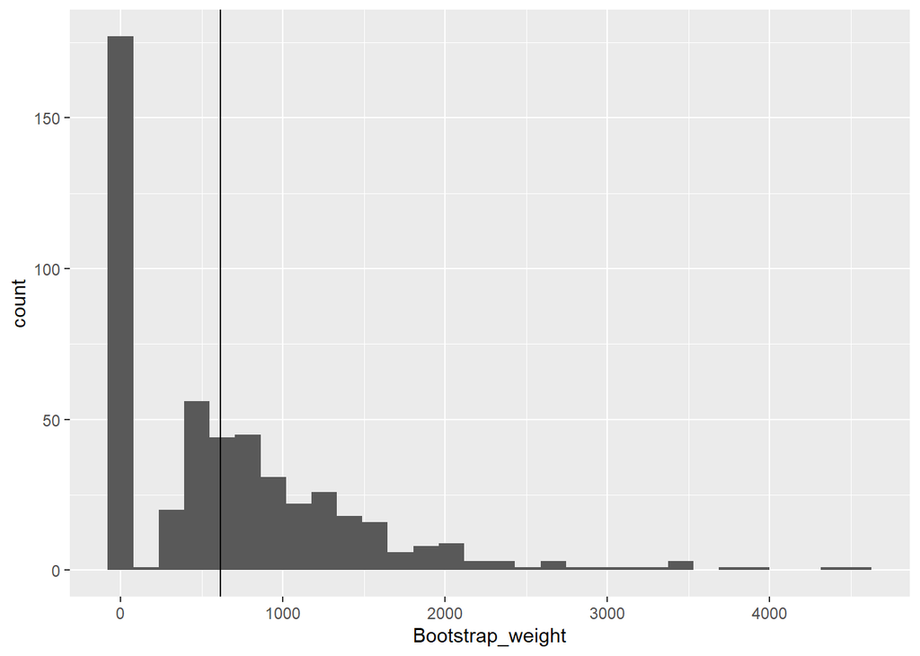

```r
gss_e_2015 |>
  slice_head() |>
  select(WGHT_EPI, starts_with("WEPI")) |>
  pivot_longer(cols = -WGHT_EPI,
               names_to = "Bootstrap_number",
               values_to = "Bootstrap_weight") |>
  ggplot() +
  geom_histogram(aes(x = Bootstrap_weight)) +
  geom_vline(aes(xintercept = WGHT_EPI))
```

WE don’t plan to use the bootstrap weights.

We begin by creating a data set for walking using the 2015 data table.

Create a table with origins and destinations for walking in 2015. I will identify the rows where the location of the activity in the episode file was “315” which is code for “walking”.

```r
walking_2015 <- gss_e_2015 |>
  dplyr::slice(unlist(rows)) |>
  dplyr::select(PUMFID:LOCATION) |>
  #dplyr::slice_head(n = 15) |>
  group_by(PUMFID) |>
  mutate(origin = lag(LOCATION),
         destination = lead(LOCATION)) |>
  #  group_by(PUMFID) %>%
  filter(LOCATION == 315) |>
  ungroup()
```

Similarly, filter origins of interest:

```r
walking_2015 <- walking_2015 |>
  filter(origin == 300 |
           origin == 301 |
           origin == 303 |
           origin == 302 |
           origin == 305 |
           origin == 306 |
           origin == 307 |
           origin == 309 |
           origin == 310)  |>
  mutate(orig_label =
           case_when(origin == 300 ~ "Home",
                     origin == 301 ~ "Work or school",
                     origin == 303 ~ "Other's home",
                     origin == 302 ~ "Business",
                     origin == 305 ~ "Outdoors",
                     origin == 306 ~ "Grocery store, other stores or mall",
                     origin == 306 ~ "Library, museum or theatre",
                     origin == 309 ~ "Restaurant, bar or club",
                     origin == 310 ~ "Place of worship"),
         orig_label = factor(orig_label))
```

```r
# change destination and origins to text column
walking_2015 <- walking_2015 |>
  # Choose destinations of interest
  filter(destination == 300 |
           destination == 301 |
           destination == 303 |
           destination == 302 |
           destination == 305 |
           destination == 306 |
           destination == 307 |
           destination == 309 |
           destination == 310 ) |>
  # Label the destinations
  mutate(dest_label =
           case_when(destination == 300 ~ "Home",
                     destination == 301 ~ "Work or school",
                     destination == 303 ~ "Other's home",
                     destination == 302 ~ "Business",
                     destination == 305 ~ "Outdoors",
                     destination == 306 ~ "Grocery store, other stores or mall",
                     destination == 306 ~ "Library, museum or theatre",
                     destination == 309 ~ "Restaurant, bar or club",
                     destination == 310 ~ "Place of worship"),
         dest_label = factor(dest_label))
```

```r
walking_2015 <- walking_2015 |>
  dplyr::select(PUMFID, WGHT_EPI, DDAY, STARTIME:dest_label) |>
  mutate(YEAR = 2015,
         MODE = "Walking")
```

Sanity check!

```r
walking_2015 |>
  group_by(orig_label,
           dest_label) |>
  count() |>
  pivot_wider(names_from = "dest_label", values_from = "n")
```

| orig_label | Business | Home | Other's home | Work or school | Grocery store, other stores or mall | Outdoors | Restaurant, bar or club | NA | Place of worship |
| --- | --- | --- | --- | --- | --- | --- | --- | --- | --- |
| Business | 1 | 2 | 1 | 4 | NA | NA | NA | NA | NA |
| Grocery store, other stores or mall | NA | 286 | 20 | 18 | 27 | 4 | 16 | 2 | NA |
| Home | 2 | 306 | 155 | 348 | 246 | 50 | 120 | 31 | 30 |
| Other's home | NA | 177 | 15 | 8 | 10 | 5 | 20 | NA | NA |
| Outdoors | NA | 54 | 6 | 2 | 1 | 15 | 8 | NA | 1 |
| Place of worship | NA | 25 | 1 | 2 | 4 | NA | 1 | 2 | NA |
| Restaurant, bar or club | 2 | 140 | 16 | 37 | 27 | 4 | 20 | 11 | 1 |
| Work or school | 2 | 303 | 14 | 58 | 37 | 11 | 58 | NA | 3 |
| NA | NA | 25 | 1 | 2 | 6 | 3 | 8 | 1 | 1 |

The most common destination for a walking trip that starts at home is `Work or school`. Notice, though that there are quite a few trips that start *and* end at Home. What are those supposed to be?

Check those home-to-home trips:

```r
walking_2015 |>
  filter(orig_label == "Home" & dest_label == "Home")
```

| PUMFID | WGHT_EPI | DDAY | STARTIME | ENDTIME | STARTMIN | ENDMIN | DURATION | LOCATION | origin | destination | orig_label | dest_label | YEAR | MODE |
| --- | --- | --- | --- | --- | --- | --- | --- | --- | --- | --- | --- | --- | --- | --- |
| 10041 | 1353.8178 | 4 | 825 | 840 | 505 | 520 | 15 | 315 | 300 | 300 | Home | Home | 2015 | Walking |
| 10065 | 500.3623 | 3 | 1200 | 1245 | 720 | 765 | 45 | 315 | 300 | 300 | Home | Home | 2015 | Walking |
| 10227 | 1362.9950 | 7 | 930 | 1010 | 570 | 610 | 40 | 315 | 300 | 300 | Home | Home | 2015 | Walking |
| 10229 | 486.0801 | 3 | 1420 | 1430 | 860 | 870 | 10 | 315 | 300 | 300 | Home | Home | 2015 | Walking |
| 10233 | 802.8968 | 2 | 815 | 855 | 495 | 535 | 40 | 315 | 300 | 300 | Home | Home | 2015 | Walking |
| 10447 | 5483.2731 | 7 | 835 | 1010 | 515 | 610 | 95 | 315 | 300 | 300 | Home | Home | 2015 | Walking |
| 10469 | 1441.4188 | 7 | 1440 | 1500 | 880 | 900 | 20 | 315 | 300 | 300 | Home | Home | 2015 | Walking |
| 10540 | 833.3518 | 6 | 1700 | 1730 | 1020 | 1050 | 30 | 315 | 300 | 300 | Home | Home | 2015 | Walking |
| 10561 | 293.9030 | 6 | 845 | 1015 | 525 | 615 | 90 | 315 | 300 | 300 | Home | Home | 2015 | Walking |
| 10752 | 848.7368 | 2 | 900 | 915 | 540 | 555 | 15 | 315 | 300 | 300 | Home | Home | 2015 | Walking |

[output cut: 296 more lines]

See PUMFID == 10041 and check the walking episode:

```r
gss_e_2015 |>
  filter(PUMFID == 10041) |>
  slice(unique(c(which(LOCATION == 315) - 1,
                 which(LOCATION == 315),
                 which(LOCATION == 315) + 1))) |>
  select(PUMFID:LOCATION)
```

| PUMFID | EPINO | WGHT_EPI | DDAY | TOTEPISO | TUI_01 | STARTIME | ENDTIME | STARTMIN | ENDMIN | DURATION | LOCATION |
| --- | --- | --- | --- | --- | --- | --- | --- | --- | --- | --- | --- |
| 10041 | 3 | 1353.818 | 4 | 19 | 27 | 810 | 825 | 490 | 505 | 15 | 300 |
| 10041 | 4 | 1353.818 | 4 | 19 | 7 | 825 | 840 | 505 | 520 | 15 | 315 |
| 10041 | 5 | 1353.818 | 4 | 19 | 9 | 840 | 1140 | 520 | 700 | 180 | 300 |

The person was at home doing 27 (personal care), then went for walk that lasted 15 minutes, came back home and spent 180 doing 9 (looking for work). So, this was a recreational/leisure trip!

QUESTION: Should we include recreational trips in our analysis? If not, then we need to filter out all home-to-home trips.

```r
save(walking_2015,
     file = paste0(here(), "/data/walking_2015.Rda"))
```

Save data for later use:

```r
save(cycling_2015,
     file = paste0(here(), "/data/cycling_2015.Rda"))
```

Save data for later use:

```r
save(walking_2005,
     file = paste0(here(), "/data/walking_2005.Rda"))
```

Save data for later use:

```r
save(cycling_2005,
     file = paste0(here(), "/data/cycling_2005.Rda"))
```

Save data for later use:

```r
save(walking_1998,
     file = paste0(here(), "/data/walking_1998.Rda"))
```

Save data for later use:

```r
save(cycling_1998,
     file = paste0(here(), "/data/cycling_1998.Rda"))
```

Save data for later use:

```r
save(walking_1992,
     file = paste0(here(), "/data/walking_1992.Rda"))
```

Save data for later use:

```r
save(cycling_1992,
     file = paste0(here(), "/data/cycling_1992.Rda"))
```

Save data for later use:

```r
save(walking_1986,
     file = paste0(here(), "/data/walking_19869.Rda"))
```